# ARMA/ARIMA/SARIMA

### Model Fitting

After second differencing `GDP`, ACF shows one significant lag, while PACF shows five. This suggests ARIMA parameters `p = [1,2,3,4,5]`, `d = [1,2]`, `q = [1]`. I’ll test these for the lowest `AIC`, `BIC`, and `AICc`, and cross-check with `auto.arima` to forecasting.

```
Model fitting with minimum AIC:
 1, 1, 1, -1871.92391061098, -1857.04266350455, -1871.79057727765

Model fitting with minimum AICc:
 1, 1, 1, -1871.92391061098, -1857.04266350455, -1871.79057727765

Model fitting with minimum BIC:
 1, 1, 1, -1871.92391061098, -1857.04266350455, -1871.79057727765
```

**auto.arima**

```
Series: ts
ARIMA(0,2,3)(1,0,1)[4]

Coefficients:
          ma1      ma2      ma3     sar1    sma1
      -0.8748  -0.0010  -0.1093  -0.6082  0.5539
s.e.   0.0572   0.0756   0.0562   0.3597  0.3727

sigma^2 = 0.0001251:  log likelihood = 935.79
AIC=-1859.59   AICc=-1859.31   BIC=-1837.29
```

### Model Diagnostics

The first ARIMA model `(1,1,1)` shows a good fit with the lowest information criteria scores, indicating effective parameter use. The residuals suggest the model captures the data’s underlying process well. The second model, which appears to be a SARIMA given the seasonal components, is more complex and doesn’t offer a significantly better fit, as the information criteria scores are marginally higher and some coefficients are not statistically significant. The first model is preferable for its simplicity and performance.

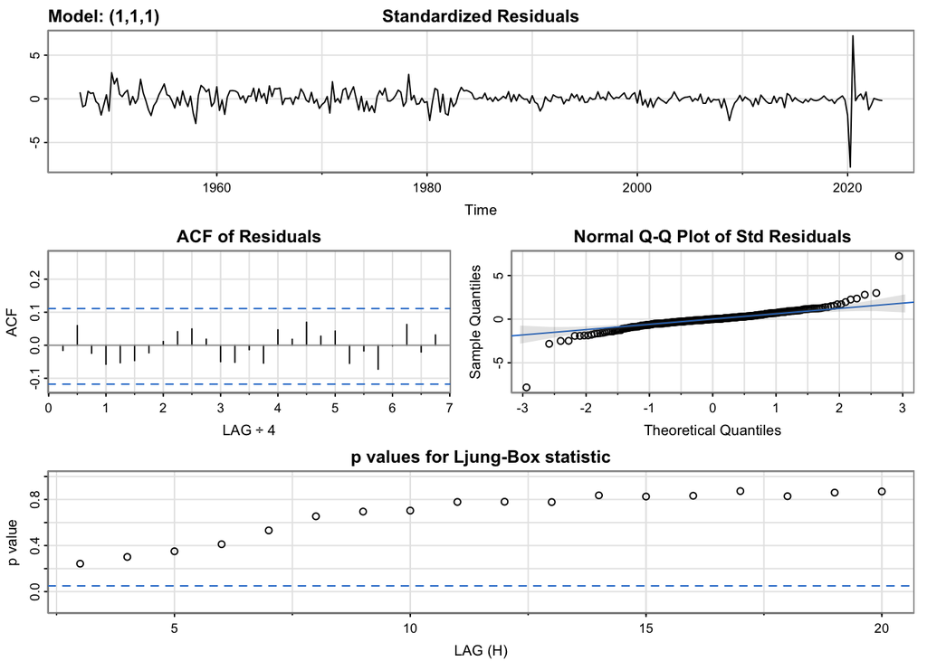

```
 [1] "Call:"
 [2] "arima(x = xdata, order = c(p, d, q), seasonal = list(order = c(P, D, Q), period = S), "
 [3] "    xreg = constant, transform.pars = trans, fixed = fixed, optim.control = list(trace = trc, "
 [4] "        REPORT = 1, reltol = tol))"
 [5] ""
 [6] "Coefficients:"
 [7] "         ar1      ma1  constant"
 [8] "      0.4412  -0.3052    0.0076"
 [9] "s.e.  0.2101   0.2191    0.0008"
[10] ""
[11] "sigma^2 estimated as 0.0001232:  log likelihood = 939.96,  aic = -1871.92"
[12] ""
[13] "$degrees_of_freedom"
[14] "[1] 302"
[15] ""
[16] "$ttable"
[17] "         Estimate     SE t.value p.value"
[18] "ar1        0.4412 0.2101  2.1002  0.0365"
[19] "ma1       -0.3052 0.2191 -1.3930  0.1646"
[20] "constant   0.0076 0.0008  9.6004  0.0000"
[21] ""
[22] "$AIC"
[23] "[1] -6.137455"
[24] ""
[25] "$AICc"
[26] "[1] -6.137194"
[27] ""
[28] "$BIC"
[29] "[1] -6.088664"
[30] ""
```

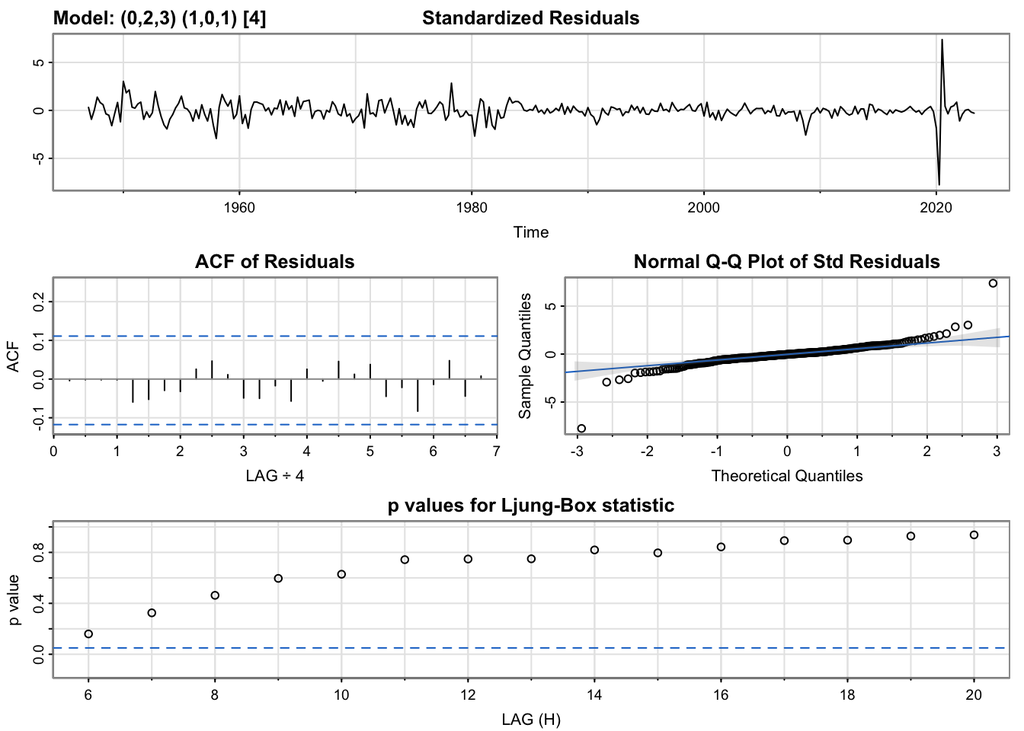

```
 [1] "Call:"
 [2] "arima(x = xdata, order = c(p, d, q), seasonal = list(order = c(P, D, Q), period = S), "
 [3] "    include.mean = !no.constant, transform.pars = trans, fixed = fixed, optim.control = list(trace = trc, "
 [4] "        REPORT = 1, reltol = tol))"
 [5] ""
 [6] "Coefficients:"
 [7] "          ma1      ma2      ma3     sar1    sma1"
 [8] "      -0.8748  -0.0010  -0.1093  -0.6082  0.5539"
 [9] "s.e.   0.0572   0.0756   0.0562   0.3597  0.3727"
[10] ""
[11] "sigma^2 estimated as 0.0001227:  log likelihood = 935.79,  aic = -1859.59"
[12] ""
[13] "$degrees_of_freedom"
[14] "[1] 299"
[15] ""
```

[output cut: 17 more lines]

Equation for `ARIMA(1,1,1)`:

$$(1 - \phi B)(1 - B)X_t = (1 + \theta B)W_t$$

```
Series: ts
ARIMA(1,1,1)

Coefficients:
         ar1      ma1
      0.9997  -0.9836
s.e.  0.0006   0.0103

sigma^2 = 0.0001276:  log likelihood = 934.67
AIC=-1863.34   AICc=-1863.26   BIC=-1852.18

Training set error measures:
                        ME       RMSE         MAE          MPE       MAPE
Training set -0.0001737751 0.01123841 0.007111044 -0.001027974 0.08112324
                  MASE      ACF1
Training set 0.2069521 0.1241003
```

### Forecasting

The forecast shows a projected increase in the log-transformed GDP, with historical data indicating a good model fit. The widening confidence intervals suggest greater uncertainty in the longer term. While useful for economic planning, these predictions rely on past trends continuing unchanged and may not account for unforeseen economic events.

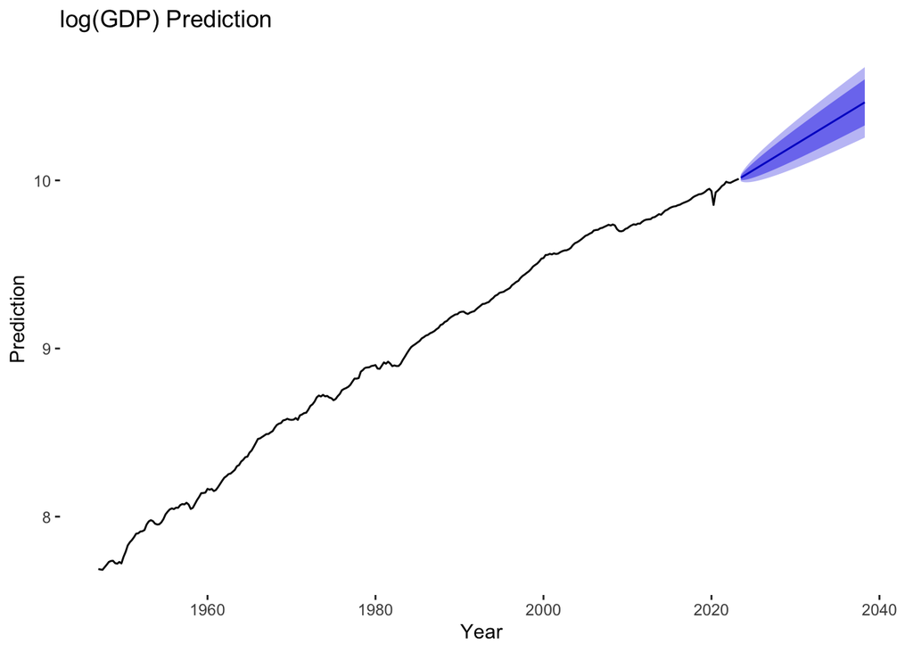

### Benchmark Method

The ARIMA model seems to closely follow the actual trend, along with the Drift model. The other models—Mean, Naive, and Seasonal Naive—diverge from the actual trend as time progresses, indicating less accuracy.

```
ARIMA Model Accuracy Metrics:
```

```
                        ME       RMSE         MAE          MPE       MAPE
Training set -0.0001737751 0.01123841 0.007111044 -0.001027974 0.08112324
                  MASE      ACF1
Training set 0.2069521 0.1241003
```

```
Mean Model Accuracy Metrics:
```

```
                       ME      RMSE       MAE        MPE     MAPE     MASE
Training set 1.560046e-17 0.6856741 0.5943983 -0.6000709 6.726537 17.29873
                  ACF1
Training set 0.9903157
```

```
Naive Model Accuracy Metrics:
```

```
                      ME       RMSE        MAE        MPE      MAPE      MASE
Training set 0.007608786 0.01356279 0.01029104 0.08636799 0.1165192 0.2994994
                  ACF1
Training set 0.1336013
```

```
Seasonal Naive Model Accuracy Metrics:
```

```
                     ME       RMSE        MAE       MPE     MAPE MASE     ACF1
Training set 0.03061763 0.04003529 0.03436081 0.3470782 0.388953    1 0.798235
```

```
Random Walk with Drift Model Accuracy Metrics:
```

```
                       ME       RMSE       MAE         MPE       MAPE      MASE
Training set 3.814826e-16 0.01122745 0.0071468 0.001228953 0.08148863 0.2079927
                  ACF1
Training set 0.1336013
```

```
Model with the best Accuracy Metrics:
 ARIMA Drift ARIMA Mean ARIMA ARIMA ARIMA
```

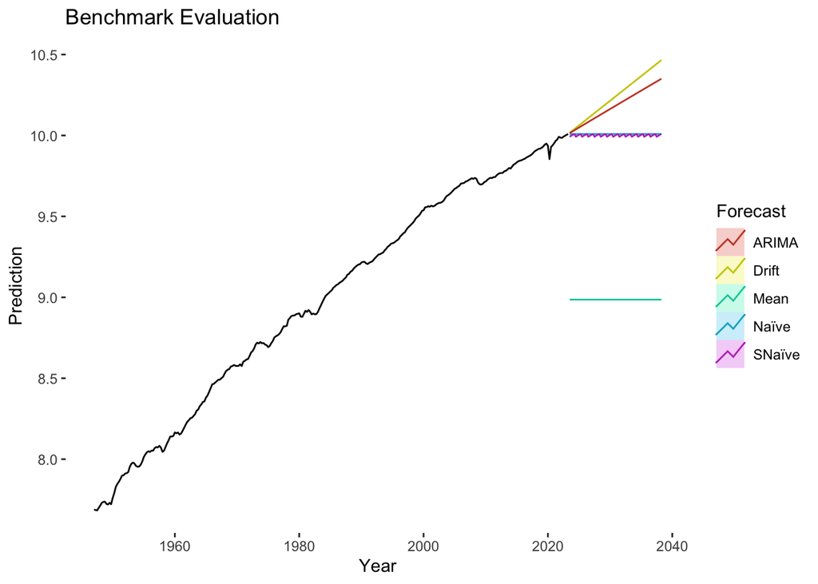

## SARIMA - 3 Month Treasury Bill

`SARIMA` models are used for treasury yields like 3-month T-bills or 20-year T-bonds because they help predict the regular ups and downs that happen throughout the year. These ups and downs can be due to when the government borrows more, changes in how often people invest, and rules that banks follow at certain times. SARIMA can catch these patterns, making it easier to guess where yields will go next, which is very important for people who invest in these securities.

### Data Processing

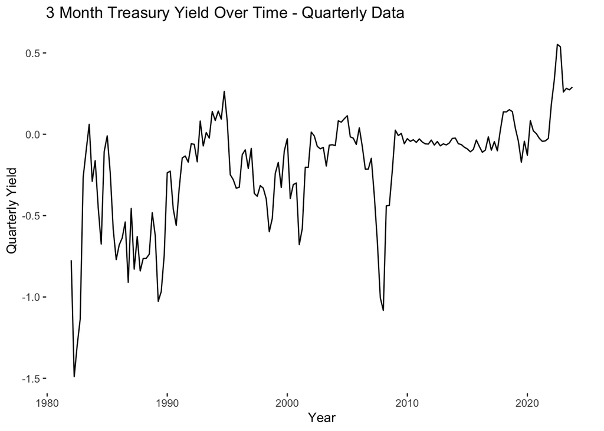

### Stationarity Check

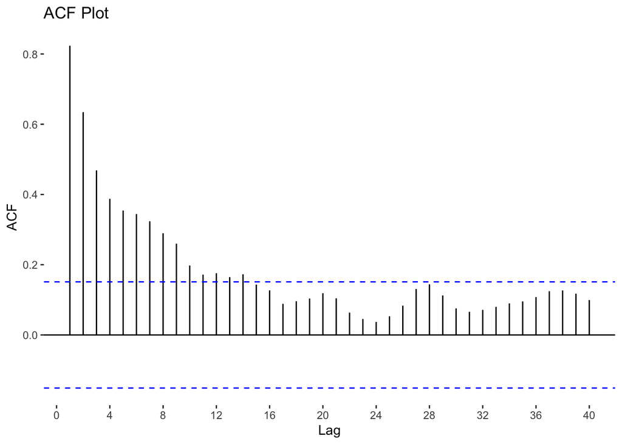

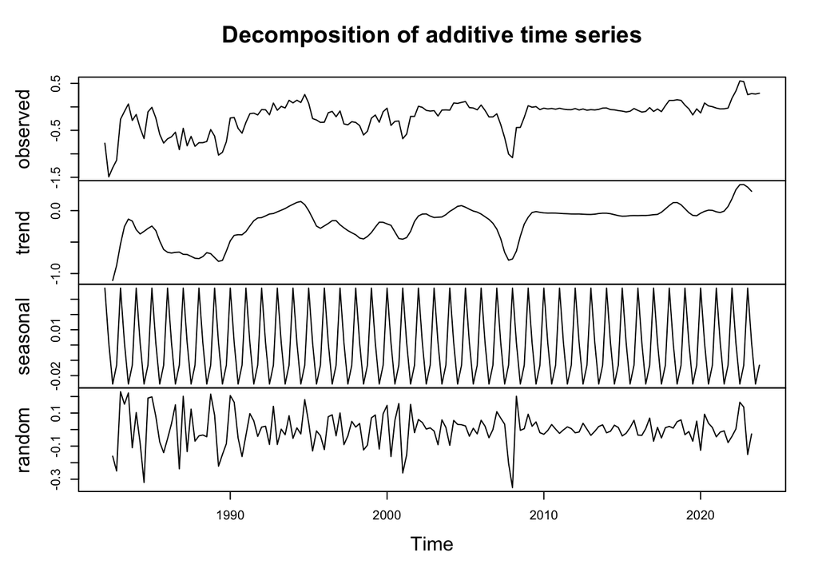

```
Augmented Dickey-Fuller Test Results:
```

```
Test Statistic: -3.318366   P-value: 0.07045011
```

```
The time series is not stationary based on the ADF test.
```

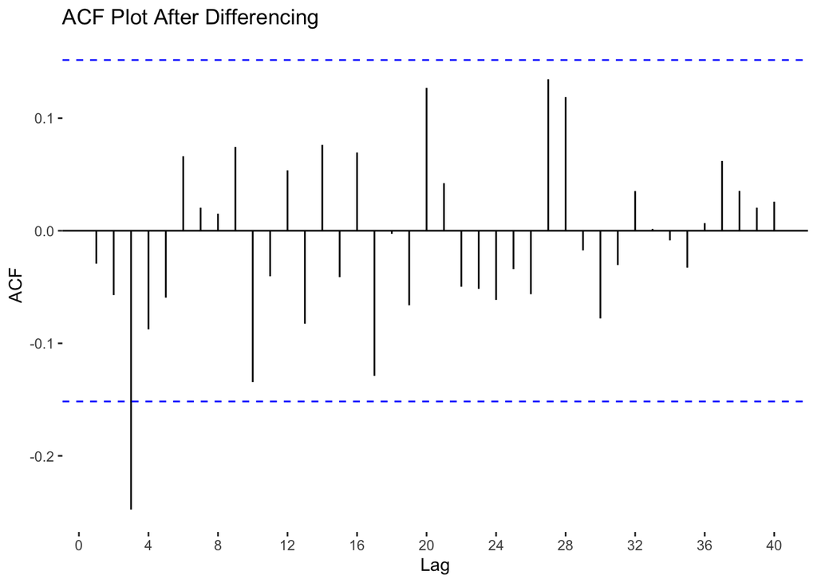

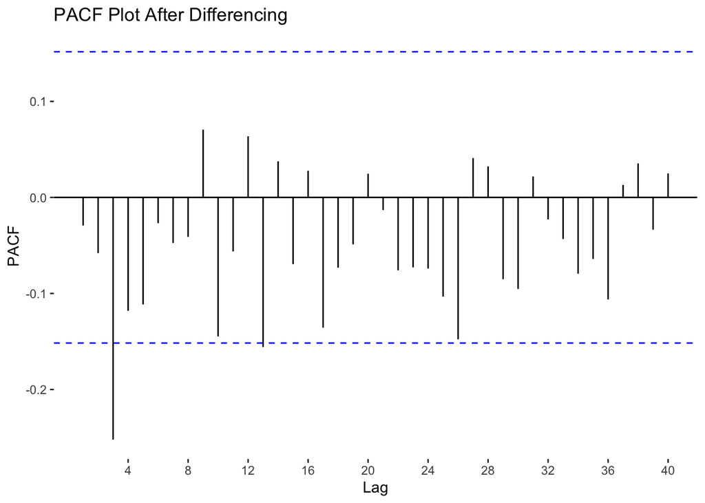

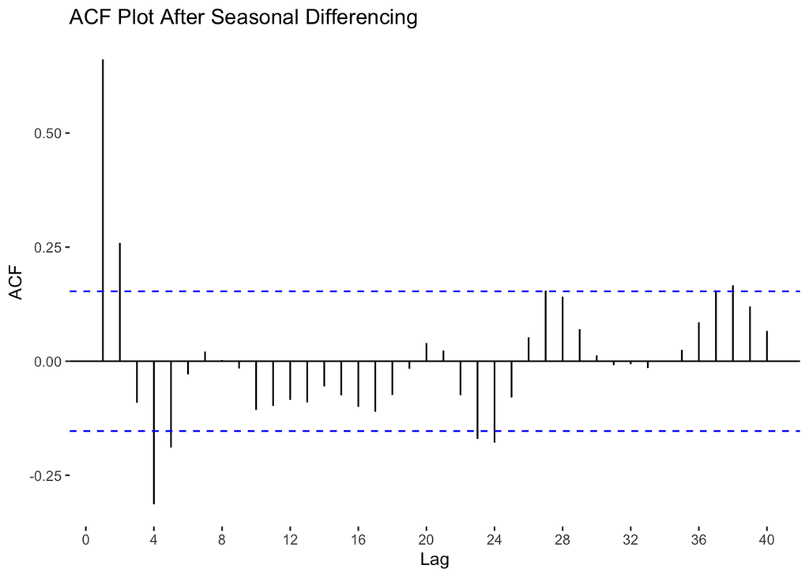

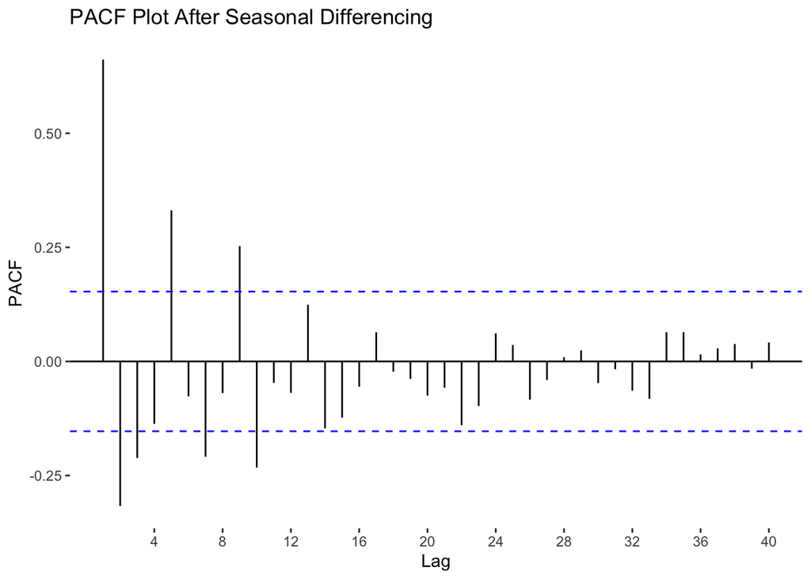

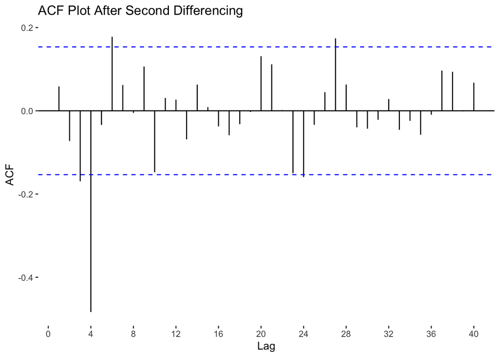

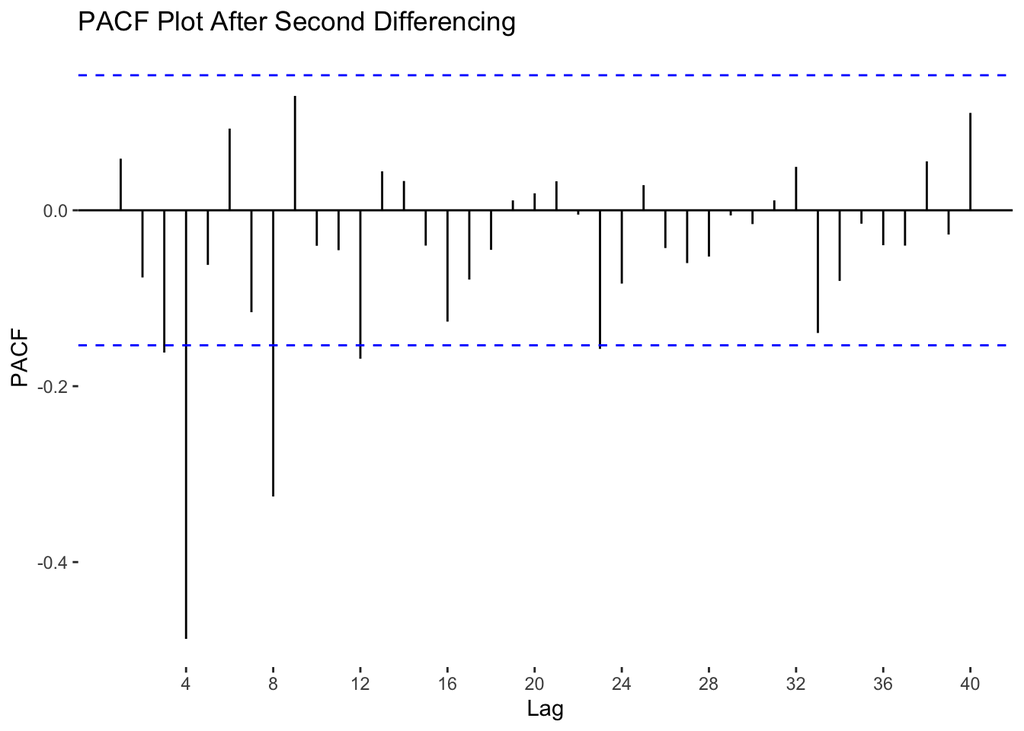

### Model Fitting

After second differencing `3 Month T-Bill Yield`, ACF shows three lags, while PACF shows four. This suggests ARIMA parameters `p = [0,1,2,3]`, `P = [2]`, `d = [1]`, `[D = 1]`, `q = [0,1,2], Q = [1]`. I’ll test these for the lowest `AIC`, `BIC`, and `AICc`, and cross-check with `auto.arima` to forecasting.

```
Minimum AIC: 1, 1, 1, 2, 1, 1, -77.5526287298902, -58.9901275250496, -77.0141671914286
```

```
Minimum BIC: 1, 1, 1, 2, 1, 1, -77.5526287298902, -58.9901275250496, -77.0141671914286
```

```
Minimum AICc: 1, 1, 1, 2, 1, 1, -77.5526287298902, -58.9901275250496, -77.0141671914286
```

**auto.arima**

```
Series: ts
ARIMA(3,1,0)(2,0,0)[4]

Coefficients:
          ar1      ar2      ar3     sar1     sar2
      -0.0812  -0.0820  -0.2835  -0.1593  -0.0340
s.e.   0.0814   0.0789   0.0780   0.0905   0.0897

sigma^2 = 0.03345:  log likelihood = 49.13
AIC=-86.25   AICc=-85.73   BIC=-67.54
```

### Model Diagnostics

In the model fitting analysis, two prominent models emerged: `SARIMA(3,1,0)(2,0,0)[4]` and `SARIMA(1,1,1)(2,1,1)[4]`. The diagnostic comparison for these models focuses on evaluating key summary statistics, including the presence of a white noise pattern in the residuals, p-values, and critical model selection criteria like AIC, AICc, and BIC.

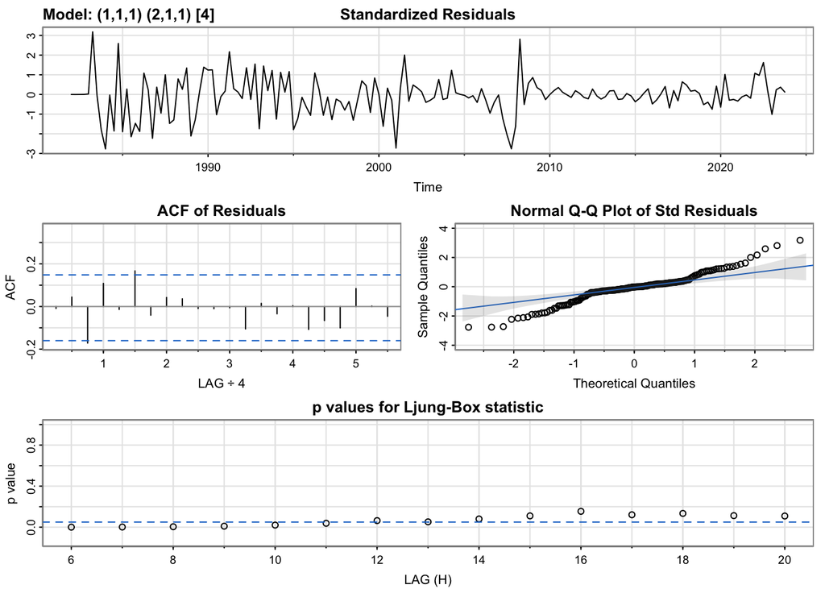

```
 [1] "Call:"
 [2] "arima(x = xdata, order = c(p, d, q), seasonal = list(order = c(P, D, Q), period = S), "
 [3] "    include.mean = !no.constant, transform.pars = trans, fixed = fixed, optim.control = list(trace = trc, "
 [4] "        REPORT = 1, reltol = tol))"
 [5] ""
 [6] "Coefficients:"
 [7] "         ar1      ma1     sar1     sar2     sma1"
 [8] "      0.8182  -1.0000  -0.1960  -0.1040  -0.8524"
 [9] "s.e.  0.0520   0.0256   0.0993   0.0982   0.0615"
[10] ""
[11] "sigma^2 estimated as 0.03124:  log likelihood = 44.78,  aic = -77.55"
[12] ""
[13] "$degrees_of_freedom"
[14] "[1] 158"
[15] ""
```

[output cut: 16 more lines]

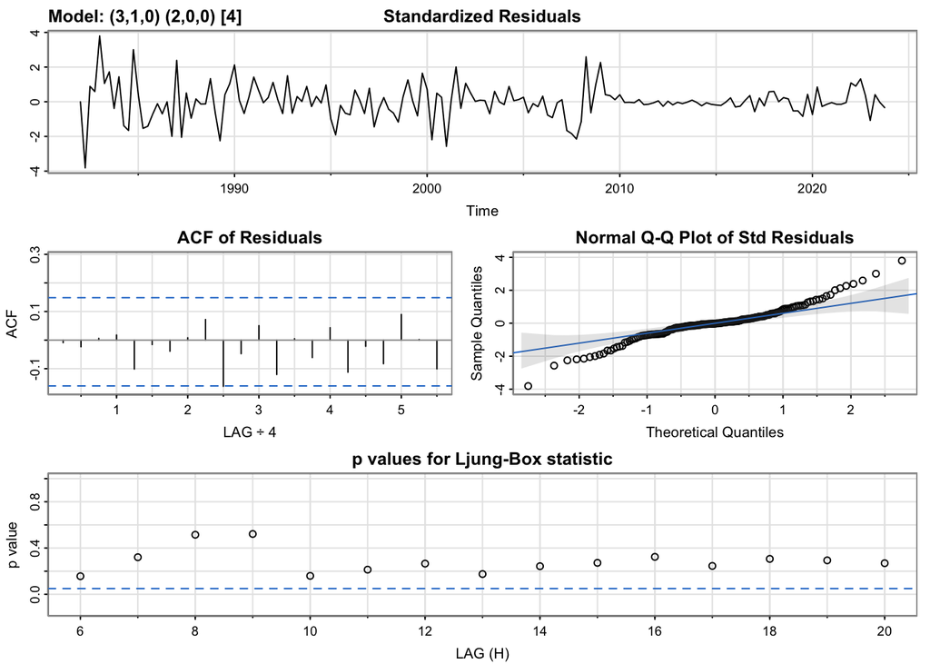

```
 [1] "Call:"
 [2] "arima(x = xdata, order = c(p, d, q), seasonal = list(order = c(P, D, Q), period = S), "
 [3] "    xreg = constant, transform.pars = trans, fixed = fixed, optim.control = list(trace = trc, "
 [4] "        REPORT = 1, reltol = tol))"
 [5] ""
 [6] "Coefficients:"
 [7] "          ar1      ar2      ar3     sar1     sar2  constant"
 [8] "      -0.0871  -0.0869  -0.2877  -0.1652  -0.0364    0.0067"
 [9] "s.e.   0.0816   0.0790   0.0780   0.0908   0.0896    0.0080"
[10] ""
[11] "sigma^2 estimated as 0.03231:  log likelihood = 49.47,  aic = -84.94"
[12] ""
[13] "$degrees_of_freedom"
[14] "[1] 161"
[15] ""
```

[output cut: 17 more lines]

Equation for `SARIMA(1,1,1)(2,1,1)[4]`:

$$(1 - \phi B)(1 - B)(1 - \Phi_1 B^s)(1 - \Phi_2 B^{2s})(1 - B^s)X_t = (1 + \theta B)(1 + \Theta_1 B^s)W_t$$

```
Series: ts
ARIMA(1,1,1)(2,1,1)[4]

Coefficients:
         ar1      ma1     sar1     sar2     sma1
      0.8182  -1.0000  -0.1960  -0.1040  -0.8524
s.e.  0.0520   0.0256   0.0993   0.0982   0.0615

sigma^2 = 0.03223:  log likelihood = 44.78
AIC=-77.55   AICc=-77.01   BIC=-58.99

Training set error measures:
                      ME      RMSE       MAE      MPE     MAPE      MASE
Training set -0.01547569 0.1740971 0.1211176 37.62815 140.1717 0.5557939
                     ACF1
Training set -0.009057403
```